# Data Visualisation: Extension Exercises

Ben Whalley

September 2021

# Logarithmic scales

A common problem when plotting some types of data is dealing with extreme values, or skewed distributions. Income data and reaction times are two notable examples: both are typically highly skewed.

We saw in an earlier worksheet that the `earnings` dataset (in `psydata`) that income is very unevenly distributed, and a small number of people earn *much* more than the average. This means a plot of income data can obscure interesting details around the median; the scale is forced to include extreme values, even though they represent very few people. This is obvious in the CPS2 data, even without including billionares like Jeff Bezos:

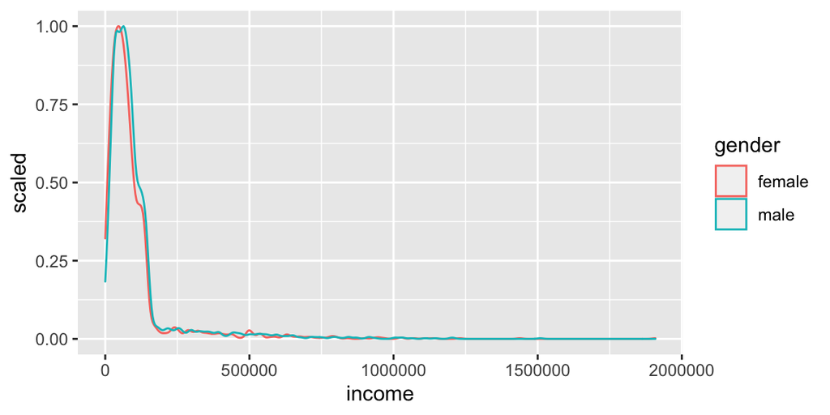

```r
earnings  %>%
  ggplot(aes(income, color=gender, y=..scaled..)) +
  geom_density()
```

One way to deal with this would be to use `filter()` to remove cases where people earned more than $150000.

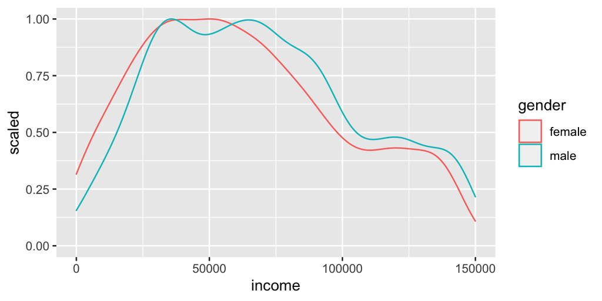

```r
earnings  %>%
  filter(income < 150000) %>%
  ggplot(aes(income, color=gender, y=..scaled..)) +
  geom_density()
```

However there is another way to replot *all* of the data but still see the gender pay gap: We can change the scale so that the units on the x axis are not evenly spaced.

This means *each axis marker represents an increasingly large difference*:

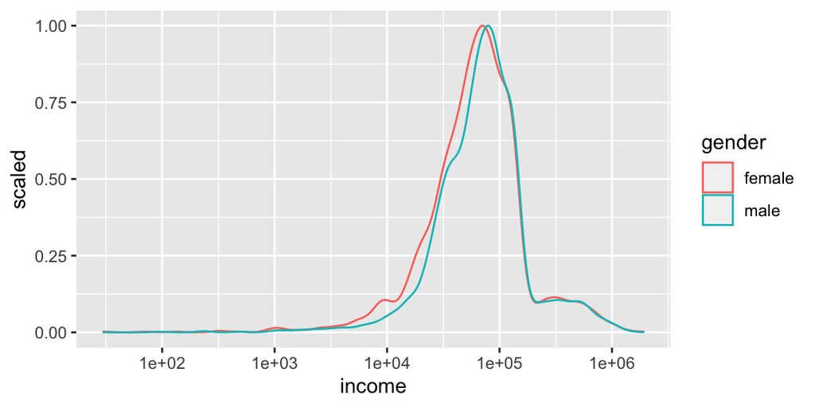

```r
earnings %>%
  ggplot(aes(income, color=gender, y=..scaled..)) +
  geom_density() +
  scale_x_log10()
```

**Explanation of the output**:

- The y axis of the graph has stayed the same, but the x axis has now changed. Rather than being equally-sized, the gaps in income represented by the gridlines are now uneven.
- Specifically, the difference between each vertical grid line is 10 times bigger than the previous one (you can find out [more about what `logn and log10` means here if you are interested](https://www.khanacademy.org/math/algebra2/x2ec2f6f830c9fb89:logs/x2ec2f6f830c9fb89:log-intro/v/logarithms)).
- R has (unhelpfully) switched to using [scientific notation](https://www.khanacademy.org/math/pre-algebra/pre-algebra-exponents-radicals/pre-algebra-scientific-notation/v/scientific-notation-old). This means that `1e+02` is equal to $1 \times 10^2$, or 100 to you and me! `1e+04` means $1 \times 10^4$, or 10,000, and so on.
- We can now see the gender pay gap much more clearly (as we also did when we simply filtered-out very high earners).

**Comments on interpreting the log-scaled graph**: Although the log scale helps us see the differences between men and women, we must remember that we are interpreting a log-scaled plot. You will notice that — in contrast to the previous plot where we simply removed very high earners — the gender differences in this plot are more obvious at lower levels of income, **even though the absolute size of the difference in dollars is just as large for high as for low earners**. This is an artefact of the plotting method because the scale is unevenly spaced: For a fixed difference in income between men and women (say $500) it will be easier to see at the bottom than at the top of the scale. Of course, the counter argument is that a $500 difference is *more important* if you earn less than $10,000 than if you earn > $200,000, so this extra emphasis is helpful. But there is no *correct* answer: the different plots emphasise different aspects of the data.

### Use a log scale with the `development` data

Use the `gapminder` dataset again.

1. Filter the data so you are only using observations from a single year
2. Plot GDP per capita (x axis) against life expectancy (y axis) using a normal scale for GDP.
3. Now replot using a log scale for GDP.
4. If it’s possible, discuss with others: what are the advantages of using a log scale in this instance? (if you are alone, perhaps make some notes on the pros and cons and have a discussion in the next session)

### Use a log scale for reaction time data

This paper presents data on reaction times in a cross sectional sample of participants of different ages: https://journals.plos.org/plosone/article?id=10.1371/journal.pone.0189598#sec016

The data are available in Excel format from PlosOne, but a (tidied up) subset of the data are available as `wii_rt` in the `psydata` package.

1. Use `wii_rt` to recreate the scatter plot from Figure 1 in the paper (use `geom_smooth` for the lines and don’t worry if the lines are not *exactly* the same).
2. Use the `scale_y_log10()` command to adjust the scale of the Y axis. The result should look something like this:

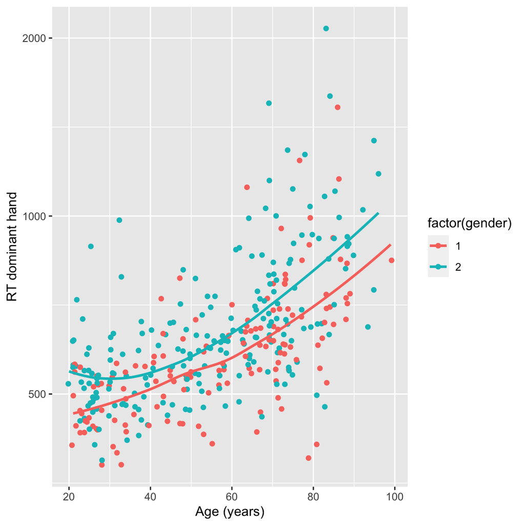

3. If you have time look at the help files for `scale_y_log10` (type `?scale_y_log10` into the console). See if you can work out how to change the years that are labelled on the x axis (the scale breaks or ‘ticks’). You may find the help files quite cryptic to begin with, but it’s often a good idea to check right down at the bottom of the document — there may be examples of usage shown there.

# Adding text

To learn how to add text to a plot, see this brief guide:

http://www.sthda.com/english/wiki/ggplot2-texts-add-text-annotations-to-a-graph-in-r-software

1. Try adding text to your new version of Bae et al. Figure 1 which includes the text from the original (note that the original Figure itself is a little misguided in providing two separate *p* values — but we will deal with that in a later workshop).

# Tufte-style plots

As mentioned in the session, Edward Tufte’s books have been influential in the field of data visualisation. His book ‘The display of quantitative information’ (Tufte 2001) is a great resource and guide.

Note that he shows how to make the examples in ‘Base R’ and using the `lattice` package, as well as with `ggplot`. For now I would recommend using the `ggplot` code.

http://motioninsocial.com/tufte/ shows how to implement many of Tufte’s ideas in ggplot. It would be a nice exercise to work through this, and attempt to plot some of `psydata` or your own data in this style.

# Publication-ready plots

Some journals have specific requirements for submitting journals; common ones include submitting in particular formats (e.g. pdf or tiff), using particular fonts etc.

There are also some common types of plots which ggplot almost, but not quite, makes out of the box.

When trying to go the last mile and polish plots for publication several additional packages may be useful.

If you have time, you could work through some of the examples on this page

- ggpubr: http://www.sthda.com/english/articles/24-ggpubr-publication-ready-plots/78-perfect-scatter-plots-with-correlation-and-marginal-histograms/

Try applying the same techniques to some of the built-in datasets, or to the plos-one datasets included in the Team site class materials, or any other data you have.

Tufte, Edward R. 2001. *The Visual Display of Quantitative Information*. Vol. 2. Graphics press Cheshire, CT.